# PA1_template

Denis Leroux

16/10/2019

## COURSERA Reproducible Research Peer Assessment Project 1

Data downloaded from https://d396qusza40orc.cloudfront.net/repdata%2Fdata%2Factivity.zip website Activity data downloaded into MasterDataFile “MDF” Process/transform the data from ‘factor’ to ‘date’

```r
path_main="C:/Users/lerouxd/Desktop/COURSERA-Repro"
setwd(path_main)

library(stats)
library(xtable)
# Activity data downloaded into MasterDataFile "MDF"
MDF=read.csv(paste(path_main,"/activity.csv",sep=""))

#Process/transform the data from 'factor' to 'date'
MDF$date = as.Date(MDF$date,"%Y-%m-%d")
```

Total steps per day

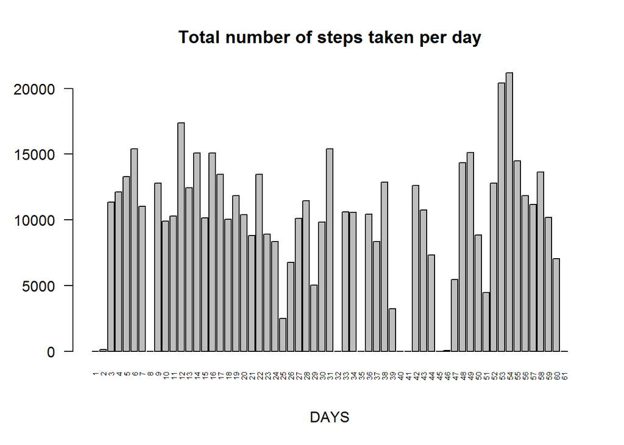

```r
table=table(MDF$date)
SPD=NULL
for (i in 1:length(table)) {
   SPD[i] = sum(MDF[MDF$date==names(table[i]),][,1],na.rm=T)
}
barplot(SPD, names.arg  = 1:61, main = "Total number of steps taken per day", xlab = "DAYS",las=2 , cex.names=0.5)
```

Mean and median total number of steps taken per day====

```r
Mean_per_day=NULL; Median_per_day=NULL;Summary=NULL;Summary2=NULL

for (i in 1:length(table)) {
   Summary[[i]]= summary(MDF[MDF$date==names(table[i]),][,1], na.rm=T)
}

Mean_per_day = unlist(lapply(Summary,"[", 4)); names(Mean_per_day) = levels(MDF$date)
Median_per_day = unlist(lapply(Summary,"[", 3)); names(Median_per_day) = levels(MDF$date)

print("Mean_per_day")
```

```
## [1] "Mean_per_day"
```

```r
print(Mean_per_day)
```

```
##  [1]        NaN  0.4375000 39.4166667 42.0694444 46.1597222 53.5416667
##  [7] 38.2465278        NaN 44.4826389 34.3750000 35.7777778 60.3541667
## [13] 43.1458333 52.4236111 35.2048611 52.3750000 46.7083333 34.9166667
## [19] 41.0729167 36.0937500 30.6284722 46.7361111 30.9652778 29.0104167
## [25]  8.6527778 23.5347222 35.1354167 39.7847222 17.4236111 34.0937500
## [31] 53.5208333        NaN 36.8055556 36.7048611        NaN 36.2465278
## [37] 28.9375000 44.7326389 11.1770833        NaN        NaN 43.7777778
## [43] 37.3784722 25.4722222        NaN  0.1423611 18.8923611 49.7881944
## [49] 52.4652778 30.6979167 15.5277778 44.3993056 70.9270833 73.5902778
## [55] 50.2708333 41.0902778 38.7569444 47.3819444 35.3576389 24.4687500
## [61]        NaN
```

```r
print("Median_per_day")
```

```
## [1] "Median_per_day"
```

```r
print(Median_per_day)
```

```
##  [1] NA  0  0  0  0  0  0 NA  0  0  0  0  0  0  0  0  0  0  0  0  0  0  0
## [24]  0  0  0  0  0  0  0  0 NA  0  0 NA  0  0  0  0 NA NA  0  0  0 NA  0
## [47]  0  0  0  0  0  0  0  0  0  0  0  0  0  0 NA
```

Calculate and report the total number of missing values in the dataset

```r
NA_MDF = sum(is.na(MDF))
print("total number of missing values in the dataset")
```

```
## [1] "total number of missing values in the dataset"
```

```r
print(NA_MDF)
```

```
## [1] 2304
```

Average daily activity pattern Make a time series plot (i.e. type = “l”) of the 5-minute interval (x-axis) and the average number of steps taken, averaged across all days (y-axis)

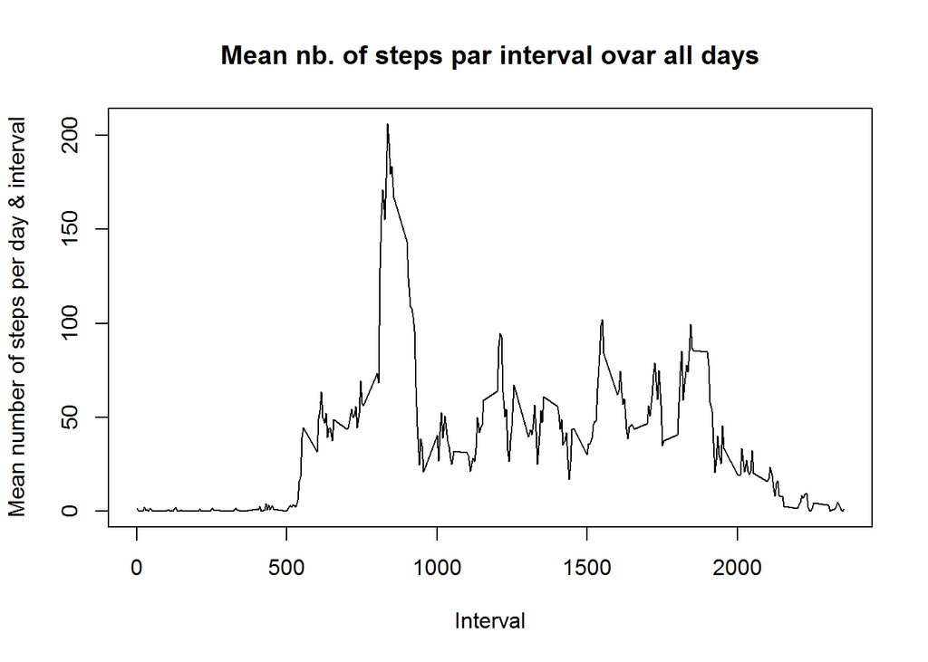

```r
step_int=as.numeric(levels(as.factor(MDF$interval)))

for (i in 1:length(step_int)) {
  Summary2[[i]]= summary(MDF[MDF$interval == step_int[i],] [,1], na.rm=T)
}

Mean_per_day.interval = unlist(lapply(Summary2,"[", 4))
names(Mean_per_day.interval) = as.character(step_int)
plot(x = step_int, y = Mean_per_day.interval , type="l", xlab = "Interval", ylab = "Mean number of steps per day & interval", main = "Mean nb. of steps par interval ovar all days")
```

```r
step_max=which(Mean_per_day.interval == max(Mean_per_day.interval))
print(paste("Max activity at interval = ", MDF$interval[step_max] , " interval, which corresponds to ", round(step_max/12, 1), "hours", sep=""))
```

```
## [1] "Max activity at interval = 835 interval, which corresponds to 8.7hours"
```

##PART B: filling in all of the missing values in the dataset by REPLACING NAs by mean

Replacing NA values in summary by zero if total nb of steps is zero for a given date

```r
SummaryB=NULL
for (i in 1:length(Summary)) {
   SummaryB[[i]] = ifelse(is.na(Summary[[i]]), 0, Summary[[i]])
}
```

Filling in all of the missing values in the dataset:

The mean for that day replaces the NA value, the new dataframe is stored as “MDFB” not to overwrite the original one

```r
   # which(is.na(MDF$steps)==T)
MDFB=MDF
for (i in 1:length(SummaryB)) {
   MDFB$steps=ifelse(is.na(MDFB$steps) & MDFB$date == levels(as.factor(MDFB$date))[i], SummaryB[[i]] [4], MDFB$steps)
}
```

Mean total number of steps taken per day after replacing NAs per mean : ‘SPDB’

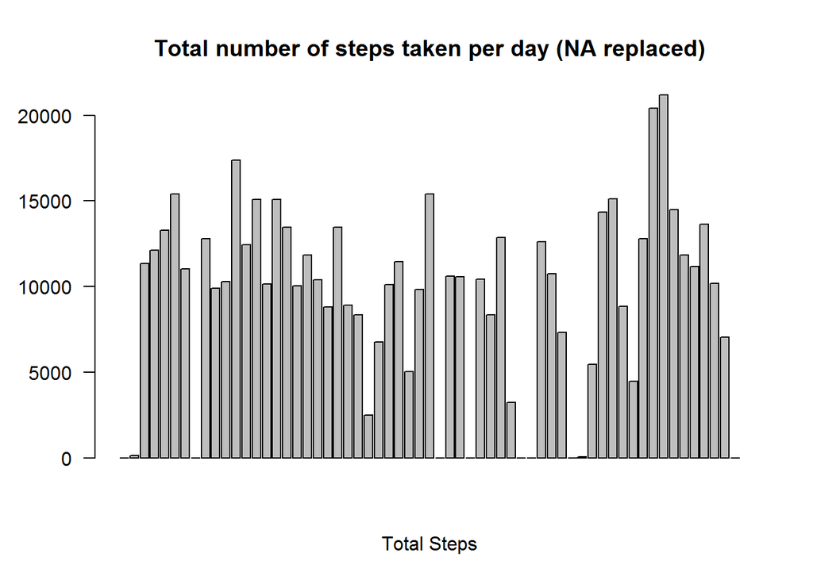

```r
tableB=table(MDFB$date)
SPDB=NULL
for (i in 1:length(tableB)) {
        SPDB[i] = sum(MDFB[MDFB$date==names(tableB[i]),][,1],na.rm=T)
}
barplot(SPDB, names.arg  = levels(MDFB$date), main = "Total number of steps taken per day (NA replaced)", xlab = "Total Steps",las=2 , cex.names=0.5)
```

Mean and median total number of steps taken per day after replacing NAs per mean : ‘SPDB’

```r
Mean_per_dayB=NULL; Median_per_dayB=NULL;SummaryB=NULL;SummaryB2=NULL
 for (i in 1:length(tableB)) {
     Mean_per_dayB[i] = round(mean(MDFB[MDFB$date==names(tableB[i]),][,1], na.rm=T),2)
     Median_per_dayB[i] = round(median(MDFB[MDFB$date==names(tableB[i]),][,1], na.rm=TRUE),2)
    SummaryB[[i]]= summary(MDFB[MDFB$date==names(tableB[i]),][,1], na.rm=T)
 }
Mean_per_dayB = unlist(lapply(SummaryB,"[", 4)); names(Mean_per_dayB) = levels(MDFB$date)
Median_per_dayB = unlist(lapply(SummaryB,"[", 3)); names(Median_per_dayB) = levels(MDFB$date)

print("Mean_per_day with NAs replaced by mean")
```

```
## [1] "Mean_per_day with NAs replaced by mean"
```

```r
print(Mean_per_dayB)
```

```
##  [1]  0.0000000  0.4375000 39.4166667 42.0694444 46.1597222 53.5416667
##  [7] 38.2465278  0.0000000 44.4826389 34.3750000 35.7777778 60.3541667
## [13] 43.1458333 52.4236111 35.2048611 52.3750000 46.7083333 34.9166667
## [19] 41.0729167 36.0937500 30.6284722 46.7361111 30.9652778 29.0104167
## [25]  8.6527778 23.5347222 35.1354167 39.7847222 17.4236111 34.0937500
## [31] 53.5208333  0.0000000 36.8055556 36.7048611  0.0000000 36.2465278
## [37] 28.9375000 44.7326389 11.1770833  0.0000000  0.0000000 43.7777778
## [43] 37.3784722 25.4722222  0.0000000  0.1423611 18.8923611 49.7881944
## [49] 52.4652778 30.6979167 15.5277778 44.3993056 70.9270833 73.5902778
## [55] 50.2708333 41.0902778 38.7569444 47.3819444 35.3576389 24.4687500
## [61]  0.0000000
```

```r
print("Median_per_day with  NAs replaced by mean")
```

```
## [1] "Median_per_day with  NAs replaced by mean"
```

```r
print(Median_per_dayB)
```

```
##  [1] 0 0 0 0 0 0 0 0 0 0 0 0 0 0 0 0 0 0 0 0 0 0 0 0 0 0 0 0 0 0 0 0 0 0 0
## [36] 0 0 0 0 0 0 0 0 0 0 0 0 0 0 0 0 0 0 0 0 0 0 0 0 0 0
```

Compare Means and Median with and whithout NAs being replaced by means on a given day: are they equal ?

```r
print("Are Mean_per_day equal for each of the 61 days?")
```

```
## [1] "Are Mean_per_day equal for each of the 61 days?"
```

```r
Mean_per_dayB == Mean_per_day
```

```
##  [1]   NA TRUE TRUE TRUE TRUE TRUE TRUE   NA TRUE TRUE TRUE TRUE TRUE TRUE
## [15] TRUE TRUE TRUE TRUE TRUE TRUE TRUE TRUE TRUE TRUE TRUE TRUE TRUE TRUE
## [29] TRUE TRUE TRUE   NA TRUE TRUE   NA TRUE TRUE TRUE TRUE   NA   NA TRUE
## [43] TRUE TRUE   NA TRUE TRUE TRUE TRUE TRUE TRUE TRUE TRUE TRUE TRUE TRUE
## [57] TRUE TRUE TRUE TRUE   NA
```

```r
print("Are Medium_per_day equal for each of the 61 days?")
```

```
## [1] "Are Medium_per_day equal for each of the 61 days?"
```

```r
Median_per_dayB == Median_per_day
```

```
##  [1]   NA TRUE TRUE TRUE TRUE TRUE TRUE   NA TRUE TRUE TRUE TRUE TRUE TRUE
## [15] TRUE TRUE TRUE TRUE TRUE TRUE TRUE TRUE TRUE TRUE TRUE TRUE TRUE TRUE
## [29] TRUE TRUE TRUE   NA TRUE TRUE   NA TRUE TRUE TRUE TRUE   NA   NA TRUE
## [43] TRUE TRUE   NA TRUE TRUE TRUE TRUE TRUE TRUE TRUE TRUE TRUE TRUE TRUE
## [57] TRUE TRUE TRUE TRUE   NA
```

Total number of steps taken per day: after replacing NAs per mean : ‘SPDB’

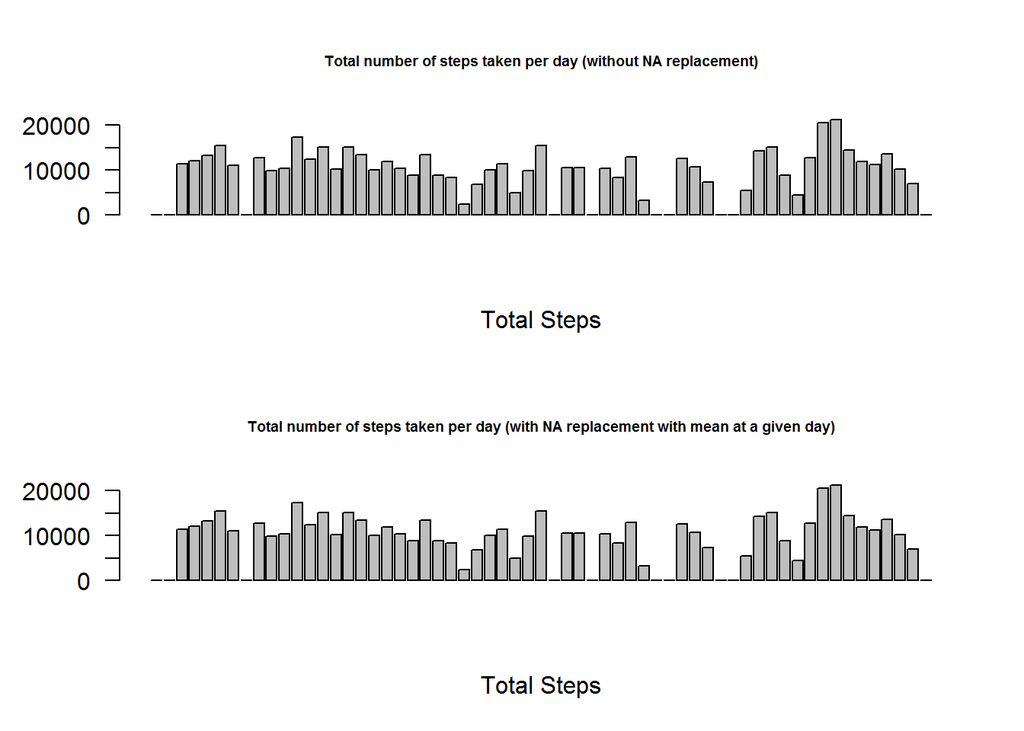

```r
tableB=table(MDFB$date)
SPDB=NULL
for (i in 1:length(tableB)) {
   SPDB[i] = sum(MDFB[MDFB$date==names(tableB[i]),][,1],na.rm=T)
}

par(mfrow=c(2,1) )
barplot(SPD, names.arg  = levels(MDFB$date), main = "Total number of steps taken per day (without NA replacement)", xlab = "Total Steps",las=2 , cex.names=0.5, cex.main=0.6)
barplot(SPDB, names.arg  = levels(MDFB$date), main = "Total number of steps taken per day (with NA replacement with mean at a given day)", xlab = "Total Steps",las=2 , cex.names=0.5, cex.main=0.6)
```

```r
SPDB == SPD
```

```
##  [1] TRUE TRUE TRUE TRUE TRUE TRUE TRUE TRUE TRUE TRUE TRUE TRUE TRUE TRUE
## [15] TRUE TRUE TRUE TRUE TRUE TRUE TRUE TRUE TRUE TRUE TRUE TRUE TRUE TRUE
## [29] TRUE TRUE TRUE TRUE TRUE TRUE TRUE TRUE TRUE TRUE TRUE TRUE TRUE TRUE
## [43] TRUE TRUE TRUE TRUE TRUE TRUE TRUE TRUE TRUE TRUE TRUE TRUE TRUE TRUE
## [57] TRUE TRUE TRUE TRUE TRUE
```

Indeed all NAs originate from unique days, in which case the total nb of steps is zero and there is no added steps in fine.

## Are there differences in activity patterns between weekdays and weekends?

Create a new factor variable in the dataset with two levels – “weekday” and “weekend”

```r
   # assign days to master data file
MDFW=cbind(MDFB, weekdays(MDF$date))
colnames(MDFW) [4] = "day"
   #split into two dataframes for weekdays (MDFD) & for weekends (MDFE))
MDFE=MDFW[(MDFW$day == "Saturday") | (MDFW$day == "Sunday"),]
MDFD=MDFW[!(MDFW$day == "Saturday") & (!MDFW$day == "Sunday"),]
```

Make a panel plot containing a time series plot (i.e. type = “l”) of the 5-minute interval (x-axis) and the average number of steps taken, averaged across all weekday days or weekend days (y-axis)

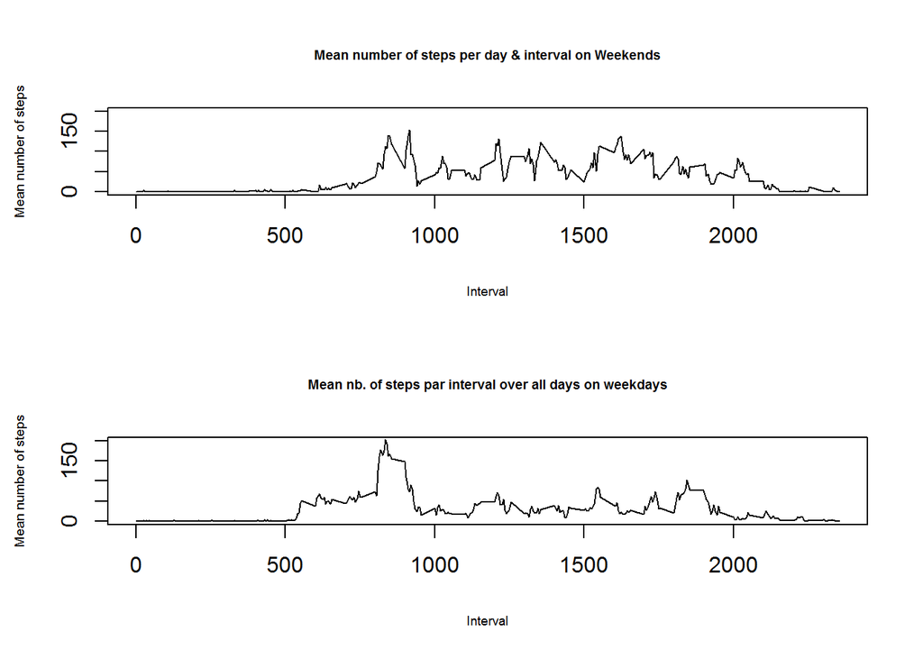

```r
SummaryB2_E=NULL; SummaryB2_D = NULL
for (i in 1:length(step_int)) {
   SummaryB2_E[[i]]= summary(MDFE[MDFE$interval == step_int[i],] [,1], na.rm=T)
   SummaryB2_D[[i]]= summary(MDFD[MDFD$interval == step_int[i],] [,1], na.rm=T)
}

Mean_per_day.interval_E = unlist(lapply(SummaryB2_E,"[", 4))
names(Mean_per_day.interval_E) = as.character(step_int)
Mean_per_day.interval_D = unlist(lapply(SummaryB2_D,"[", 4))
names(Mean_per_day.interval_D) = as.character(step_int)

par(mfrow=c(2,1))
plot(x = step_int, y = Mean_per_day.interval_E , type="l", xlab = "Interval", ylab = "Mean number of steps", main = "Mean number of steps per day & interval on Weekends",cex.main=0.6, cex.lab= 0.6, ylim=c(0,200))
plot(x = step_int, y = Mean_per_day.interval_D , type="l", xlab = "Interval", ylab = "Mean number of steps", main = "Mean nb. of steps par interval over all days on weekdays",cex.main=0.6, cex.lab= 0.6,  ylim=c(0,200))
```

```r
step_max_B=which(Mean_per_day.interval == max(Mean_per_day.interval))
```